# Predicting Diabetes

Swati Misra

2023-11-08

# 1. Introduction

This dataset is originally from the National Institute of Diabetes and Digestive and Kidney Diseases. I found this data on Kaggle at this [link](https://www.kaggle.com/datasets/iammustafatz/diabetes-prediction-dataset/data). This dataset takes into account several diagnostic measurements to make the prediction, including gender, age, hypertension, etc. I chose this dataset to analyze because I have always been interested in using data science techniques to make predictive models for diseases such as diabetes. I will be investigating the effects of variables such as BMI, Age, Blood Pressure, smoking history, and more on predicting diabetes diagnoses.

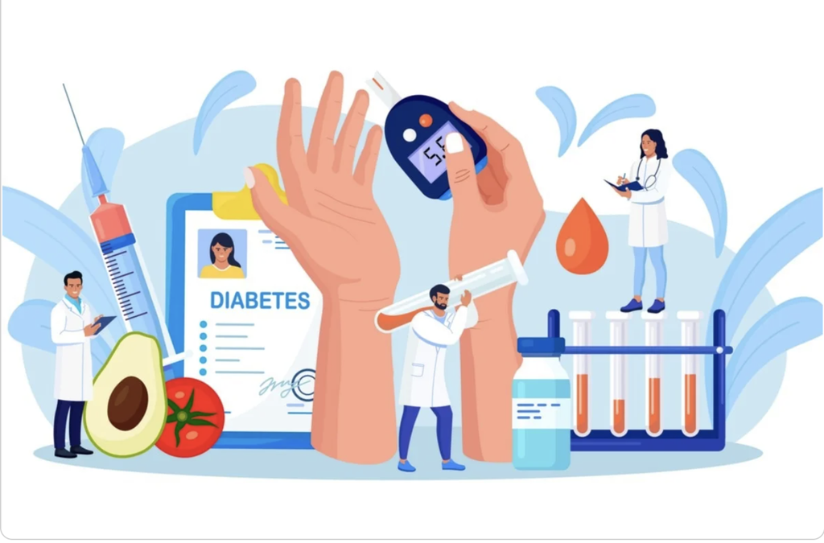

> Buravleva Stock, Shutterstock.com

# 2. How I Prepared the Data

After finding the data on Kaggle, I downloaded the dataset as a .csv file and moved it into the same directory as my RMarkdown file. I was then able to import it into my RMarkdown report and converted it into a tibble utilizing R commands.

There were 35816 patients that did not have smoking history information in the dataset. I removed these data values from the data set in order to perform the analysis. For the variables hypertension, heart disease, and diabetes, I changed the factors of 0 and 1 to the condition they represented in order to provide more clarity in the dataset. Lastly, I turned the categorical variables of gender, hypertension, heart disease, and diabetes into factors to make them more memory efficient and specify the categories of the data. I also changed the variable names to exclude the underscores as well as arranged them to the order of decreasing age. When preparing this data, I came across the issue of dealing with the value names given First, the individuals without smoking history information were labeled with a “No Info” in the data set. I first changed these values to ‘NA’ before removing them from the dataset using the na.omit() function.

```
## # A tibble: 64,184 × 9
##    Gender   Age Hypertension `Heart Disease` `Smoking History`   BMI
##    <fct>  <dbl> <fct>        <fct>           <fct>             <dbl>
##  1 Female    80 Not detected Detected        never              25.2
##  2 Male      80 Not detected Not detected    former             24.4
##  3 Female    80 Detected     Not detected    never              27.3
##  4 Female    80 Not detected Not detected    never              37.3
##  5 Male      80 Not detected Not detected    never              22.1
##  6 Female    80 Detected     Not detected    never              44.1
##  7 Female    80 Not detected Not detected    former             22.0
##  8 Female    80 Not detected Not detected    never              20.2
##  9 Female    80 Not detected Detected        never              29.6
## 10 Male      80 Not detected Not detected    never              30.0
## # ℹ 64,174 more rows
## # ℹ 3 more variables: `HbA1c Level` <dbl>, `Blood Glucose Level` <int>,
## #   Diabetes <fct>
```

# 3.

[output not shown]

# 4. Univariate Analysis

## 4A) Distribution of Smoking History

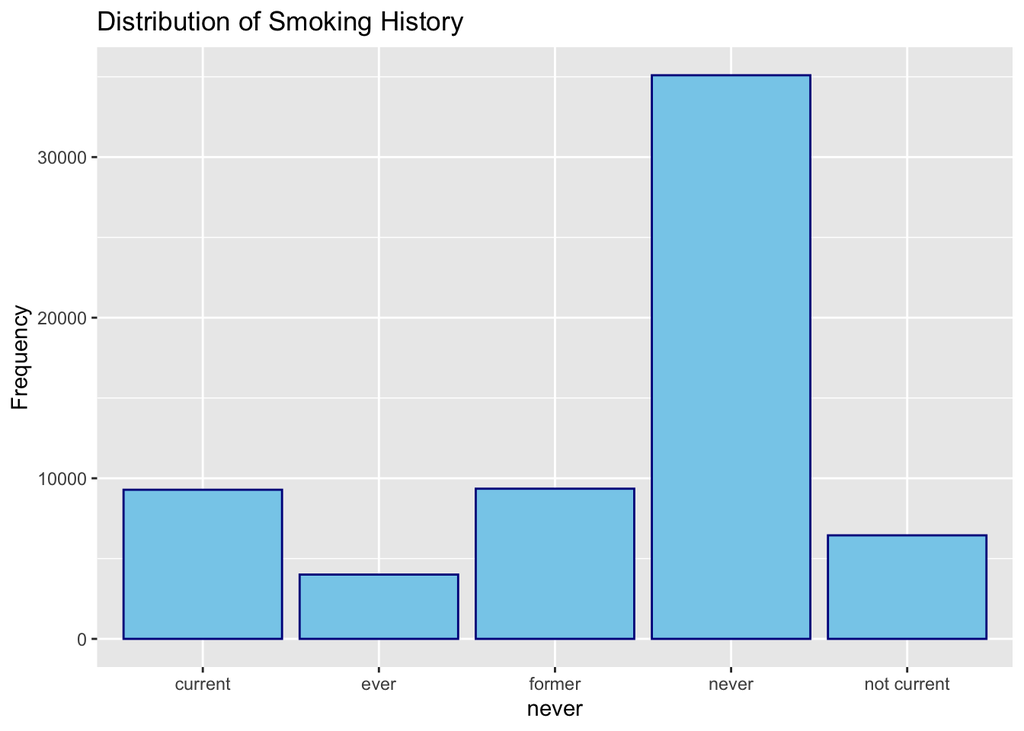

```
## [1] "The frequencies are:"
## variable1
##     current        ever      former       never not current
##        9286        4004        9352       35095        6447
```

The majority of patients said they never smoked while the smallest number of patients said they had smoked at some point in their lives.

## 4B) Distribution of Heart Disease

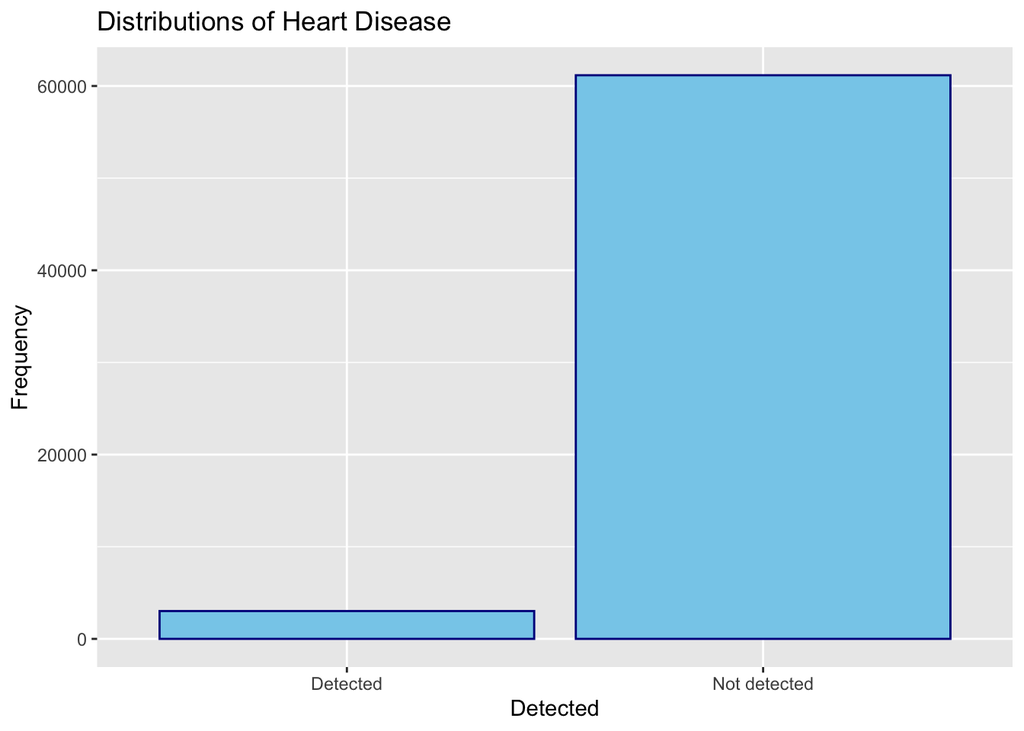

```
## [1] "The frequencies are:"
## variable1
##     Detected Not detected
##         3019        61165
```

Most of the patients were not diagnosed with heart disease.

## 4C) Distribution of Diabetes

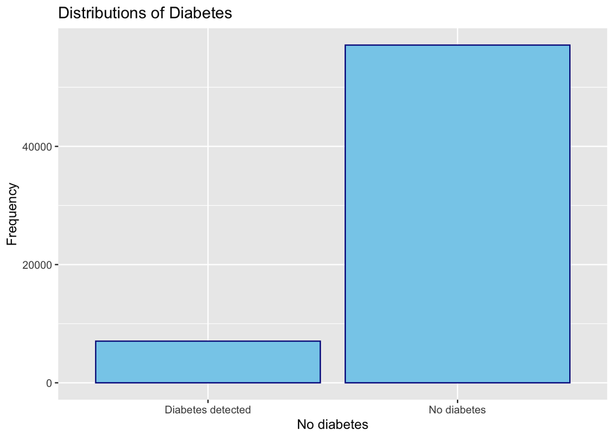

```
## [1] "The frequencies are:"
## variable1
## Diabetes detected       No diabetes
##              7046             57138
```

Most of the patients were not diagnosed with diabetes.

## 4D) Distribution of Hypertension

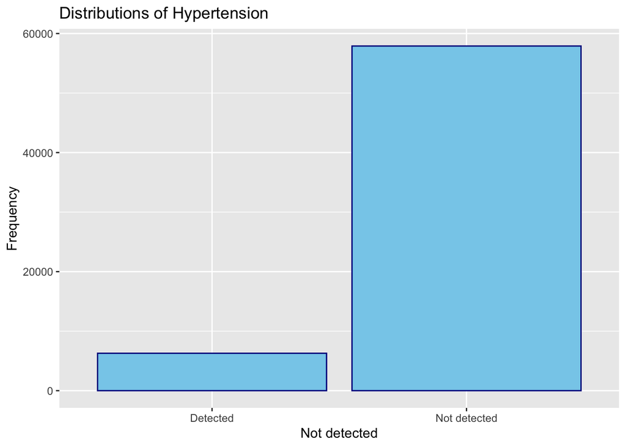

```
## [1] "The frequencies are:"
## variable1
##     Detected Not detected
##         6283        57901
```

Most of the patients were not diagnosed with hypertension.

# 5. Multivariate Analysis

## 5A) BMI and Age Categorized by Diabetes Presence

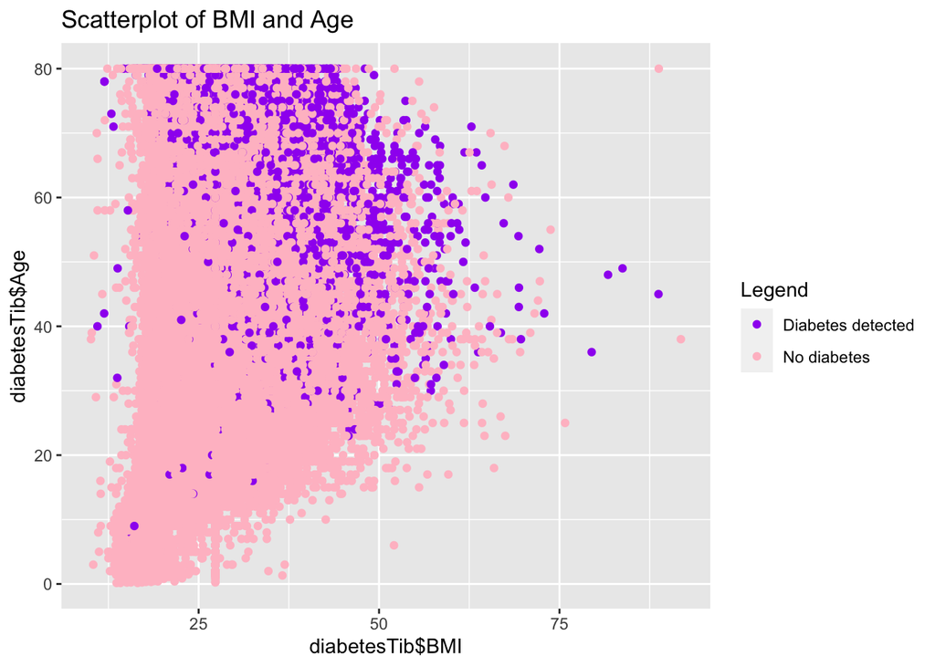

```
## [1] "The correlation coefficient of this relationship is 0.16 ."
## [1] "This is a weaker relationship between the two variables."
```

## 5B) BMI and HbA1c Level Categorized by Hypertension Presence

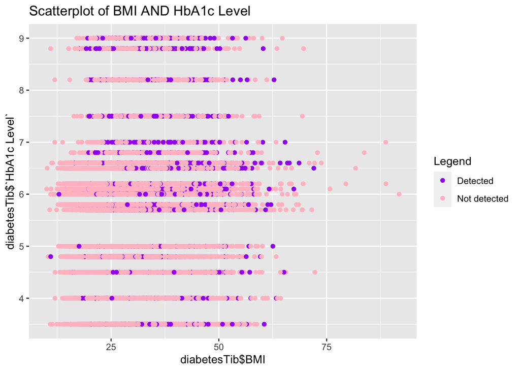

```
## [1] "The correlation coefficient of this relationship is 0.08 ."
## [1] "This is a weaker relationship between the two variables."
```

## 5C) Age and Blood Glucose Level Categorized by Heart Disease Presence

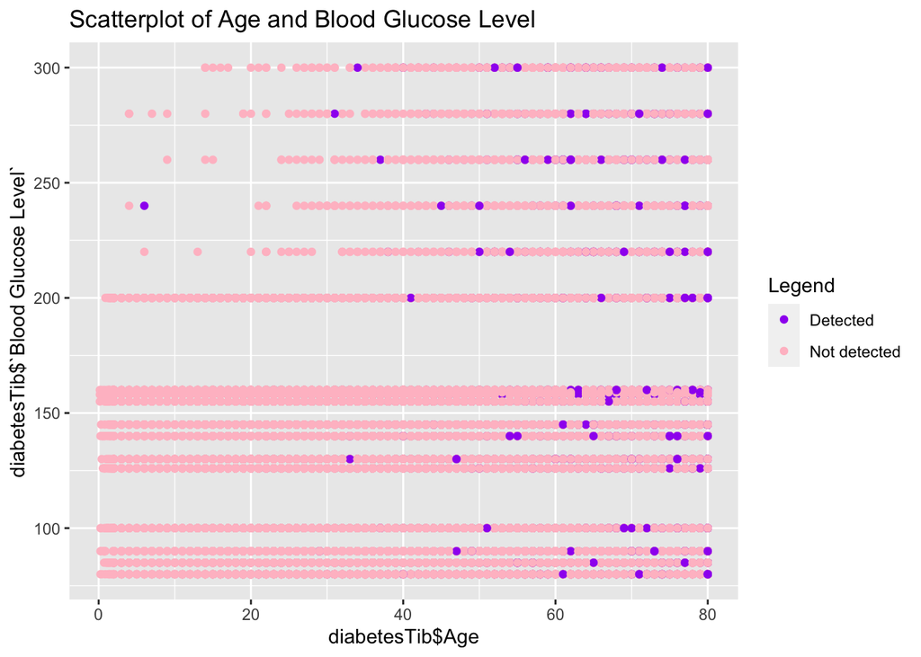

```
## [1] "The correlation coefficient of this relationship is 0.12 ."
## [1] "This is a weaker relationship between the two variables."
```

## 5D) Blood Glucose Level and HbA1c Level Categorized by Heart Disease Presence

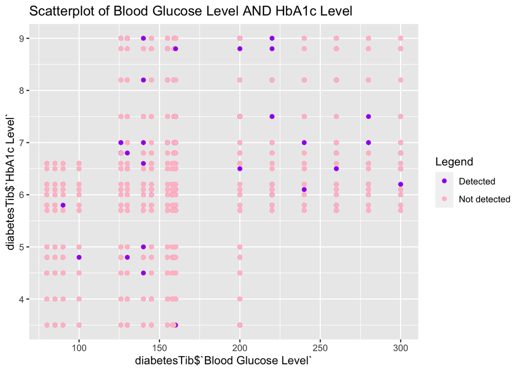

```
## [1] "The correlation coefficient of this relationship is 0.19 ."
## [1] "This is a weaker relationship between the two variables."
```

# 6 Reproducibility Resources

The GitHub repository can be accessed at this [link](https://github.com/swatimisra/Project2_Diabetes).

Project2.Rmd is the RMarkdown file with all code, comments, and conclusions typed.

Project2.html is the html file that contains the final report for the project.

diabetes.png is the picture file for the picture linked in the RMarkdown and the html file.

diabetes_prediction_dataset.csv is the .csv file that contains all data values before I cleaned and reshaped them.

# 7. Conclusion

As seen by Figure 5A, there seems to be a weak positive relationship between Age and BMI. In the scatterplot, most of the data points for patients that have diabetes were older and had higher BMIs. In Figure 5b, BMI and HbA1c levels also have a weak positive relationship.The data points also seemed to be randomly distributed dependent on detection of Hypertension. Both Blood Glucose Level and HbA1c level and Age and Blood Glucose Level have a weak positive relationship as seen in Figures 5D and 5C. These plots are separated by presence of Heart disease, and these points seem to be randomly distributed through the graph. I expected these variables to have stronger relationships as these variables are normally associated with increased risk of Diabetes.

# 8. References

“Chatgpt.” ChatGPT, openai.com/chatgpt. Accessed 9 Nov. 2023.

Mustafa, Mohammed. “Diabetes Prediction Dataset.” Kaggle, 8 Apr. 2023, www.kaggle.com/datasets/iammustafatz/diabetes-prediction-dataset/data.